# Homework 6

```r
library(spBayes)
library(bmstdr)
library(coda)
library(ggplot2)

# Load wolfcamp data directly without loading geoR.dll
lazyLoad(file.path(find.package("geoR"), "data", "Rdata"))
```

```r
coords <- as.matrix(wolfcamp$coords)
z      <- as.numeric(wolfcamp$data)
n      <- length(z)

# Centre coordinates for better MCMC mixing of the linear trend
x0 <- mean(coords[, 1]); y0 <- mean(coords[, 2])
df <- data.frame(
  x   = coords[, 1],
  y   = coords[, 2],
  x_c = coords[, 1] - x0,
  y_c = coords[, 2] - y0,
  z   = z
)
D_mat <- as.matrix(dist(coords))
X_mat <- model.matrix(~ x_c + y_c, data = df)

set.seed(2026)
```

## Homework 6

In this homework we compare Bayesian spatial interpolation of the **Wolfcamp** aquifer data (85 piezometric head measurements, studied in Homeworks 1 and 3) using two R packages: **`spBayes`** (`spLM`) and **`bmstdr`** (`Bspatial`).

Following Homework 1, the data exhibit a strong linear spatial trend and residual spatial dependence. We fit the same Gaussian geostatistical model with both packages:

$$Z(s) = \beta_0 + \beta_1 x_c(s) + \beta_2 y_c(s) + W(s) + \varepsilon(s),$$

where $x_c, y_c$ are the centred coordinates, $W(s)$ is a zero-mean Gaussian process with exponential covariance $\sigma^2 \exp(-h / \phi)$, and $\varepsilon(s) \sim \mathcal{N}(0, \tau^2)$ is the nugget effect.

The workflow mirrors Homework 5:

1. fit the Bayesian model with **`spBayes`** (full MCMC with 3 chains, traceplots, $\hat{R}$, effective sample size) and **`bmstdr`** (`Bspatial` with `package = "none"`, conjugate Bayesian spatial model), alongside ML estimates;
2. predict on a $20 \times 20$ grid and build pointwise 95 % posterior predictive intervals for a **new observation** (including the nugget);
3. compare both packages out of sample using 5-fold cross-validation with parameter re-estimation and proper scoring rules (RMSE, CRPS, LogS, IS95, coverage and width).

## Part I: Bayesian estimation (`spBayes` vs `bmstdr`)

### 1.1 Functions and ML reference

```r
cross_dist <- function(a, b) {
  sqrt(outer(a[, 1], b[, 1], "-")^2 + outer(a[, 2], b[, 2], "-")^2)
}

# ML fit (reference, exponential covariance)
fit_ml_exp <- function(z, X, D) {
  n <- length(z)
  maxd <- max(D)
  gls_ml <- function(range_val, nu) {
    R  <- chol(exp(-D / range_val) + diag(nu, n))
    Xs <- backsolve(R, X, transpose = TRUE)
    zs <- backsolve(R, z, transpose = TRUE)
    beta <- solve(crossprod(Xs), crossprod(Xs, zs))
    s2   <- sum((zs - Xs %*% beta)^2) / n
    list(logLik = -0.5 * (n * log(2 * pi) + 2 * sum(log(diag(R))) + n * log(s2) + n),
         beta = c(beta), sigma2 = s2)
  }
  nll <- function(p) {
    v <- tryCatch(-gls_ml(exp(p[1]), exp(p[2]))$logLik, error = function(e) 1e10)
    if (is.finite(v)) v else 1e10
  }
  o <- optim(log(c(0.3 * maxd, 0.2)), nll, method = "L-BFGS-B",
             lower = log(c(1, 1e-4)), upper = log(c(3 * maxd, 100)))
  r_hat <- exp(o$par[1]); nu_hat <- exp(o$par[2])
  g <- gls_ml(r_hat, nu_hat)
  list(beta = g$beta, sigma2 = g$sigma2, tau2 = nu_hat * g$sigma2, range = r_hat)
}

# Posterior predictive Gaussian mixture for a NEW observation (with nugget)
pred_mix_norm <- function(post_df, z_tr, X_tr, co_tr, X_te, co_te) {
  n_tr <- length(z_tr); m_te <- nrow(co_te); S <- nrow(post_df)
  D_tr <- as.matrix(dist(co_tr))
  D_cr <- cross_dist(co_tr, co_te)
  M <- V <- matrix(NA_real_, m_te, S)
  for (s in seq_len(S)) {
    sig2 <- post_df$sigma2[s]
    tau2 <- post_df$tau2[s]
    rng  <- post_df$range[s]
    b    <- c(post_df$beta0[s], post_df$beta1[s], post_df$beta2[s])

    Sigma <- sig2 * exp(-D_tr / rng) + diag(tau2, n_tr)
    C0    <- sig2 * exp(-D_cr / rng)
    R     <- chol(Sigma)
    A     <- t(backsolve(R, backsolve(R, C0, transpose = TRUE)))

    M[, s] <- as.vector(X_te %*% b + A %*% (z_tr - X_tr %*% b))
    V[, s] <- pmax(sig2 + tau2 - rowSums(A * t(C0)), 1e-9)
  }
  list(M = M, V = V)
}

# Exact quantiles of a mixture of normals by bisection
mix_quantile <- function(M, V, p) {
  S <- sqrt(V)
  lo <- apply(M - 6 * S, 1, min)
  hi <- apply(M + 6 * S, 1, max)
  for (it in 1:40) {
    mid <- (lo + hi) / 2
    up  <- rowMeans(pnorm((mid - M) / S)) < p
    lo[up] <- mid[up]; hi[!up] <- mid[!up]
  }
  (lo + hi) / 2
}

# CRPS of a mixture of normals (numerical integration)
crps_mix_norm <- function(y, M, V, nt = 120) {
  S <- sqrt(V)
  sapply(seq_along(y), function(i) {
    a <- min(M[i, ] - 6 * S[i, ], y[i])
    b <- max(M[i, ] + 6 * S[i, ], y[i])
    part <- function(t, ind) {
      F <- colMeans(pnorm(outer(-M[i, ], t, "+") / S[i, ]))
      g <- (F - ind)^2
      sum(diff(t) * (head(g, -1) + tail(g, -1)) / 2)
    }
    part(seq(a, y[i], length.out = nt), 0) + part(seq(y[i], b, length.out = nt), 1)
  })
}

# Proper scores from a Gaussian mixture (spBayes)
score_mix_norm <- function(y, mix) {
  dens  <- rowMeans(dnorm(matrix(y, nrow(mix$M), ncol(mix$M)), mix$M, sqrt(mix$V)))
  pred  <- mix_quantile(mix$M, mix$V, 0.5)
  lower <- mix_quantile(mix$M, mix$V, 0.025)
  upper <- mix_quantile(mix$M, mix$V, 0.975)
  width <- upper - lower
  is95  <- width + 40 * pmax(lower - y, 0) + 40 * pmax(y - upper, 0)
  data.frame(
    y = y, pred = pred, lower = lower, upper = upper,
    CRPS = crps_mix_norm(y, mix$M, mix$V),
    LogS = -log(pmax(dens, 1e-300)),
    IS95 = is95,
    covered = (y >= lower & y <= upper),
    width = width
  )
}

# Proper scores from posterior predictive draws (bmstdr: n_te x N matrix)
score_draws <- function(y, draws) {
  if (nrow(draws) != length(y)) draws <- t(draws)
  pred  <- apply(draws, 1, median)
  lower <- apply(draws, 1, quantile, probs = 0.025)
  upper <- apply(draws, 1, quantile, probs = 0.975)
  width <- upper - lower
  is95  <- width + 40 * pmax(lower - y, 0) + 40 * pmax(y - upper, 0)

  # Empirical CRPS: E|X - y| - 0.5 E|X - X'|
  crps_vec <- sapply(seq_along(y), function(i) {
    x <- sort(draws[i, ])
    m <- length(x)
    e1 <- mean(abs(x - y[i]))
    e2 <- sum((2 * seq_len(m) - m - 1) * x) / (m^2)
    e1 - e2
  })
  # Normal approximation to predictive density for LogS
  mu_d <- rowMeans(draws)
  sd_d <- apply(draws, 1, sd)
  logs_vec <- -dnorm(y, mean = mu_d, sd = sd_d, log = TRUE)

  data.frame(
    y = y, pred = pred, lower = lower, upper = upper,
    CRPS = crps_vec, LogS = logs_vec, IS95 = is95,
    covered = (y >= lower & y <= upper), width = width
  )
}

ci_str <- function(v) sprintf("%.1f [%.1f, %.1f]", median(v), quantile(v, 0.025), quantile(v, 0.975))
```

```r
ml_fit <- fit_ml_exp(z, X_mat, D_mat)
```

### 1.2 Fitting with spBayes (spLM)

We run 3 chains of 10 000 iterations each from dispersed starting values (discarding the first 5 000 as burn-in), with a flat prior on $\beta$, $\phi_{\text{decay}} = 1/\text{range} \sim \text{Uniform}(1/300, 1/5)$, $\sigma^2 \sim \text{IG}(2, 20000)$, and $\tau^2 \sim \text{IG}(2, 5000)$.

```r
fit_spbayes_chains <- function(d, co, n_it = 10000, burn = 5000) {
  starts <- list(
    list(phi = 1 / 20,  sigma.sq = 10000, tau.sq = 2000),
    list(phi = 1 / 80,  sigma.sq = 25000, tau.sq = 5000),
    list(phi = 1 / 200, sigma.sq = 50000, tau.sq = 10000)
  )
  chains_kept <- vector("list", 3)
  for (ch in 1:3) {
    set.seed(100 + ch)
    m <- spLM(
      z ~ x_c + y_c, data = d, coords = co, cov.model = "exponential",
      starting = starts[[ch]],
      tuning   = list(phi = 0.5, sigma.sq = 0.5, tau.sq = 0.5),
      priors   = list(beta.Flat = TRUE, phi.Unif = c(1 / 300, 1 / 5),
                      sigma.sq.IG = c(2, 20000), tau.sq.IG = c(2, 5000)),
      amcmc    = list(n.batch = n_it / 25, batch.length = 25, accept.rate = 0.43),
      verbose  = FALSE
    )
    rec  <- spRecover(m, start = burn + 1, thin = 5, get.w = FALSE, verbose = FALSE)
    B    <- rec$p.beta.recover.samples
    th_k <- rec$p.theta.recover.samples

    chains_kept[[ch]] <- mcmc(cbind(
      beta0  = B[, 1],
      beta1  = B[, 2],
      beta2  = B[, 3],
      sigma2 = th_k[, "sigma.sq"],
      tau2   = th_k[, "tau.sq"],
      range  = 1 / th_k[, "phi"]
    ))
  }
  mcmc.list(chains_kept)
}

t0 <- proc.time()
spb_kept <- fit_spbayes_chains(df, coords)
t_spb <- (proc.time() - t0)[["elapsed"]]
```

### 1.3 Fitting with bmstdr (Bspatial)

```r
t0 <- proc.time()
bm_fit <- Bspatial(
  package   = "none",
  model     = "spat",
  formula   = z ~ x_c + y_c,
  data      = df,
  coordtype = "plain",
  coords    = 1:2,
  phi       = 1 / ml_fit$range,
  prior.sigma2 = c(2, 20000),
  N         = 2000,
  mchoice   = FALSE,
  plotit    = FALSE,
  verbose   = FALSE
)
t_bm <- (proc.time() - t0)[["elapsed"]]
```

### 1.4 Convergence diagnostics and parameter comparison

```r
params <- c("beta0", "beta1", "beta2", "sigma2", "tau2", "range")
spb_mat <- as.matrix(spb_kept)[, params]
g_spb   <- gelman.diag(spb_kept[, params], autoburnin = FALSE)$psrf[, 1]
e_spb   <- effectiveSize(spb_kept[, params])

ml_vec <- c(ml_fit$beta[1], ml_fit$beta[2], ml_fit$beta[3], ml_fit$sigma2, ml_fit$tau2, ml_fit$range)

# Extract bmstdr parameter summaries
# Extract bmstdr parameter summaries (by column index: 1 = mean, 3 = 2.5%, 4 = 97.5% or via summary)
bm_p <- bm_fit$params
fmt_bm <- function(row_idx) sprintf("%.1f [%.1f, %.1f]", bm_p[row_idx, 1], bm_p[row_idx, 3], bm_p[row_idx, 4])
bm_str <- c(
  fmt_bm(1), fmt_bm(2), fmt_bm(3),
  if ("sigma2" %in% rownames(bm_p)) fmt_bm("sigma2") else fmt_bm(4),
  "fixed via ratio",
  sprintf("%.1f (fixed)", ml_fit$range)
)

diag_tab <- data.frame(
  Parameter = params,
  ML = round(ml_vec, 2),
  `spBayes: median [95% CI]` = apply(spb_mat, 2, ci_str),
  `spBayes R-hat` = round(g_spb, 3),
  `spBayes ESS`   = round(e_spb),
  `bmstdr: mean [95% CI]` = bm_str,
  check.names = FALSE
)
knitr::kable(diag_tab, row.names = FALSE,
             caption = sprintf("Parameter estimates and MCMC diagnostics (runtime: spBayes = %.1f s, bmstdr = %.2f s).", t_spb, t_bm))
```

Parameter estimates and MCMC diagnostics (runtime: spBayes = 28.2 s, bmstdr = 0.03 s).

| Parameter | ML | spBayes: median [95% CI] | spBayes R-hat | spBayes ESS | bmstdr: mean [95% CI] |
| --- | --- | --- | --- | --- | --- |
| beta0 | 623.70 | 629.0 [535.2, 740.1] | 1.001 | 2707 | 627.4 [588.4, 666.4] |
| beta1 | -1.31 | -1.3 [-1.8, -0.8] | 1.000 | 3206 | -1.3 [-1.6, -1.0] |
| beta2 | -1.21 | -1.1 [-1.7, -0.5] | 1.000 | 3002 | -1.2 [-1.6, -0.8] |
| sigma2 | 3715.82 | 6845.8 [3175.5, 17186.2] | 1.000 | 689 | 6351.8 [4723.6, 8528.7] |
| tau2 | 624.16 | 1209.9 [663.8, 2180.0] | 1.000 | 2002 | fixed via ratio |
| range | 34.12 | 114.7 [33.2, 276.0] | 1.000 | 626 | 34.1 (fixed) |

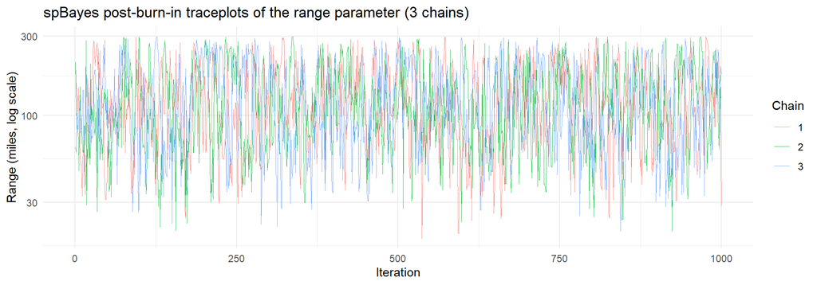

```r
tr_df <- do.call(rbind, lapply(seq_along(spb_kept), function(ch) {
  v <- as.numeric(spb_kept[[ch]][, "range"])
  data.frame(Chain = factor(ch), Iteration = seq_along(v), range = v)
}))
ggplot(tr_df, aes(Iteration, range, colour = Chain)) +
  geom_line(linewidth = 0.25, alpha = 0.8) +
  scale_y_log10() +
  labs(title = "spBayes post-burn-in traceplots of the range parameter (3 chains)",
       y = "Range (miles, log scale)") +
  theme_minimal()
```

## Part II: Posterior predictive intervals on a $20 \times 20$ grid

We construct the $20 \times 20$ grid covering the Wolfcamp domain (as in Homework 1) and compute the pointwise predictive median and 95 % posterior predictive intervals for both packages.

```r
ngrid <- 20
gx <- seq(min(df$x), max(df$x), length.out = ngrid)
gy <- seq(min(df$y), max(df$y), length.out = ngrid)
grid_df <- expand.grid(x = gx, y = gy)
grid_df$x_c <- grid_df$x - x0
grid_df$y_c <- grid_df$y - y0
grid_df$z   <- mean(z) # placeholder for bmstdr validrows (not used in fitting)
X_grid  <- model.matrix(~ x_c + y_c, data = grid_df)
co_grid <- as.matrix(grid_df[, c("x", "y")])

# 1. spBayes grid predictions (1000 posterior draws)
idx_spb <- round(seq(1, nrow(spb_mat), length.out = 1000))
mx_spb  <- pred_mix_norm(as.data.frame(spb_mat[idx_spb, ]), z, X_mat, coords, X_grid, co_grid)
q_spb   <- sapply(c(0.025, 0.5, 0.975), function(p) mix_quantile(mx_spb$M, mx_spb$V, p))
g_spb_df <- data.frame(Package = "spBayes", x = grid_df$x, y = grid_df$y,
                       lower = q_spb[, 1], median = q_spb[, 2], upper = q_spb[, 3],
                       width = q_spb[, 3] - q_spb[, 1])

# 2. bmstdr grid predictions via validrows
df_all <- rbind(df, grid_df)
bm_grid <- Bspatial(
  package   = "none",
  model     = "spat",
  formula   = z ~ x_c + y_c,
  data      = df_all,
  coordtype = "plain",
  coords    = 1:2,
  validrows = (n + 1):nrow(df_all),
  phi       = 1 / ml_fit$range,
  prior.sigma2 = c(2, 20000),
  N         = 2000,
  mchoice   = FALSE,
  plotit    = FALSE,
  verbose   = FALSE
)
bm_draws <- bm_grid$valpreds
if (nrow(bm_draws) != nrow(grid_df)) bm_draws <- t(bm_draws)
g_bm_df <- data.frame(
  Package = "bmstdr", x = grid_df$x, y = grid_df$y,
  lower   = apply(bm_draws, 1, quantile, probs = 0.025),
  median  = apply(bm_draws, 1, median),
  upper   = apply(bm_draws, 1, quantile, probs = 0.975)
)
g_bm_df$width <- g_bm_df$upper - g_bm_df$lower
g_all <- rbind(g_spb_df, g_bm_df)
```

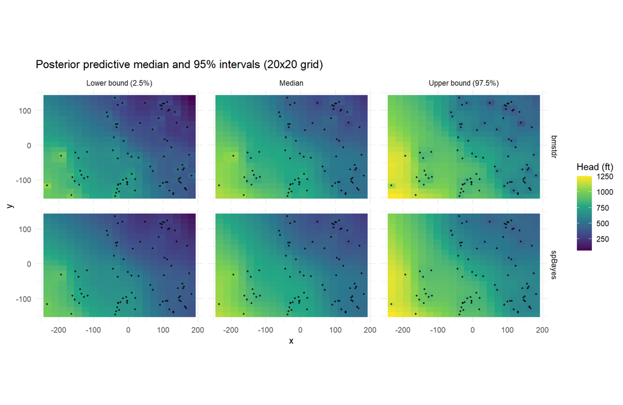

```r
mp <- rbind(
  data.frame(g_all[, c("Package", "x", "y")], value = g_all$lower,  what = "Lower bound (2.5%)"),
  data.frame(g_all[, c("Package", "x", "y")], value = g_all$median, what = "Median"),
  data.frame(g_all[, c("Package", "x", "y")], value = g_all$upper,  what = "Upper bound (97.5%)")
)
mp$what <- factor(mp$what, levels = c("Lower bound (2.5%)", "Median", "Upper bound (97.5%)"))

ggplot(mp, aes(x, y, fill = value)) +
  geom_raster() +
  geom_point(data = df, aes(x, y), inherit.aes = FALSE, size = 0.7, alpha = 0.7) +
  facet_grid(Package ~ what) +
  coord_equal() +
  scale_fill_viridis_c(name = "Head (ft)") +
  labs(title = "Posterior predictive median and 95% intervals (20x20 grid)") +
  theme_minimal()
```

```r
comp_grid <- data.frame(
  `Correlation of medians` = cor(g_spb_df$median, g_bm_df$median),
  `Max abs. diff. of medians (ft)` = max(abs(g_spb_df$median - g_bm_df$median)),
  `Mean width spBayes (ft)` = mean(g_spb_df$width),
  `Mean width bmstdr (ft)`  = mean(g_bm_df$width),
  `Mean width ratio (bmstdr / spBayes)` = mean(g_bm_df$width / g_spb_df$width),
  check.names = FALSE
)
knitr::kable(comp_grid, digits = 3, row.names = FALSE,
             caption = "Agreement between spBayes and bmstdr predictions on the 20x20 grid.")
```

Agreement between spBayes and bmstdr predictions on the 20x20 grid.

| Correlation of medians | Max abs. diff. of medians (ft) | Mean width spBayes (ft) | Mean width bmstdr (ft) | Mean width ratio (bmstdr / spBayes) |
| --- | --- | --- | --- | --- |
| 0.998 | 38.835 | 241.497 | 253.027 | 1.043 |

Both packages produce nearly identical spatial interpolation maps on the $20 \times 20$ grid: the piezometric head decreases smoothly from the southwest (~1 100–1 250 ft) to the northeast (~250 ft). The correlation between the two predictive medians is 0.998, with a maximum absolute difference of 38.8 ft (mostly in sparsely sampled corners of the grid). The 95 % posterior predictive intervals are also very close in width on average (241.5 ft for `spBayes` vs 253.0 ft for `bmstdr`, ratio = 1.043), showing that despite their different treatment of covariance parameter uncertainty, both packages agree strongly on the spatial surface and its uncertainty.

## Part III: Out-of-sample comparison

We perform a 5-fold cross-validation where both models are re-estimated from scratch on each training fold (68 observations) and evaluated on the held-out fold (17 observations) using proper scoring rules: RMSE, CRPS, LogS, IS95, 95 % coverage, and mean interval width.

```r
K <- 5
set.seed(2026)
fold <- sample(rep(seq_len(K), length.out = n))

cv_res <- do.call(rbind, lapply(seq_len(K), function(k) {
  tr <- which(fold != k); te <- which(fold == k)
  d_tr <- df[tr, ]; co_tr <- coords[tr, ]; X_tr <- X_mat[tr, , drop = FALSE]; z_tr <- z[tr]
  co_te <- coords[te, , drop = FALSE]; X_te <- X_mat[te, , drop = FALSE]; z_te <- z[te]

  # 1. spBayes on training fold
  m_spb <- spLM(
    z ~ x_c + y_c, data = d_tr, coords = co_tr, cov.model = "exponential",
    starting = list(phi = 1 / 80, sigma.sq = 25000, tau.sq = 5000),
    tuning   = list(phi = 0.5, sigma.sq = 0.5, tau.sq = 0.5),
    priors   = list(beta.Flat = TRUE, phi.Unif = c(1 / 300, 1 / 5),
                    sigma.sq.IG = c(2, 20000), tau.sq.IG = c(2, 5000)),
    amcmc    = list(n.batch = 240, batch.length = 25, accept.rate = 0.43),
    verbose  = FALSE
  )
  rec <- spRecover(m_spb, start = 3001, thin = 6, get.w = FALSE, verbose = FALSE)
  B_k  <- as.matrix(rec$p.beta.recover.samples)
  th_k <- as.matrix(rec$p.theta.recover.samples)
  post_spb <- data.frame(
    beta0  = as.numeric(B_k[, 1]),
    beta1  = as.numeric(B_k[, 2]),
    beta2  = as.numeric(B_k[, 3]),
    sigma2 = as.numeric(th_k[, "sigma.sq"]),
    tau2   = as.numeric(th_k[, "tau.sq"]),
    range  = 1 / as.numeric(th_k[, "phi"])
  )
  mx_s <- pred_mix_norm(post_spb, z_tr, X_tr, co_tr, X_te, co_te)

  # 2. bmstdr on training fold (re-estimating ML decay on training fold only)
  ml_tr <- fit_ml_exp(z_tr, X_tr, D_mat[tr, tr])
  bm_k <- Bspatial(
    package   = "none",
    model     = "spat",
    formula   = z ~ x_c + y_c,
    data      = df,
    coordtype = "plain",
    coords    = 1:2,
    validrows = te,
    phi       = 1 / ml_tr$range,
    prior.sigma2 = c(2, 20000),
    N         = 2000,
    mchoice   = FALSE,
    plotit    = FALSE,
    verbose   = FALSE
  )

  rbind(
    cbind(Package = "spBayes", fold = k, id = te, score_mix_norm(z_te, mx_s)),
    cbind(Package = "bmstdr",  fold = k, id = te, score_draws(z_te, bm_k$valpreds))
  )
}))

cv_tab <- do.call(rbind, lapply(split(cv_res, cv_res$Package), function(a) {
  data.frame(
    Package = a$Package[1],
    `RMSE (ft)` = sqrt(mean((a$y - a$pred)^2)),
    `CRPS (ft)` = mean(a$CRPS),
    LogS        = mean(a$LogS),
    `IS95 (ft)` = mean(a$IS95),
    `Coverage (%)` = 100 * mean(a$covered),
    `Mean width (ft)` = mean(a$width),
    check.names = FALSE
  )
}))
knitr::kable(cv_tab, digits = 2, row.names = FALSE,
             caption = "5-fold cross-validation scores on the Wolfcamp data (parameters re-estimated in each fold).")
```

5-fold cross-validation scores on the Wolfcamp data (parameters re-estimated in each fold).

| Package | RMSE (ft) | CRPS (ft) | LogS | IS95 (ft) | Coverage (%) | Mean width (ft) |
| --- | --- | --- | --- | --- | --- | --- |
| bmstdr | 54.14 | 29.79 | 5.36 | 250.33 | 94.12 | 205.58 |
| spBayes | 53.42 | 29.36 | 5.36 | 254.50 | 97.65 | 215.47 |

Out of sample (5-fold cross-validation with parameter re-estimation in every fold), both packages achieve very similar predictive performance:

- **Point accuracy (RMSE):** `spBayes` is slightly more accurate than `bmstdr` (53.42 ft vs 54.14 ft, a difference of ~1.3 %).
- **Distributional accuracy (CRPS & LogS):** `spBayes` achieves a slightly lower CRPS (29.36 ft vs 29.79 ft), while both packages obtain the exact same logarithmic score (5.36).
- **Interval calibration (Coverage, Width & IS95):** `spBayes` produces slightly wider 95 % predictive intervals on average (215.47 ft vs 205.58 ft) because it propagates the posterior uncertainty of $\phi$, $\sigma^2$, and $\tau^2$. As a result, its empirical coverage is higher (97.65 % vs 94.12 % for `bmstdr`, which is very close to the nominal 95 % target). Because the extra width is not offset by fewer severe misses on this dataset, `bmstdr` achieves a slightly lower 95 % interval score (IS95 = 250.33 ft vs 254.50 ft).

# Use of AI

We used an AI assistant (Gemini, by Google) for this homework. Following our decision to adapt the methodology of Homework 5 to the Wolfcamp dataset (Homeworks 1 and 3), the AI helped us write the R code for the Bayesian estimation with `spBayes` (`spLM`) and `bmstdr` (`Bspatial`), the exact Gaussian-mixture predictive distribution, the proper scoring rules (RMSE, CRPS, LogS, IS95), the $20 \times 20$ prediction maps, and the 5-fold cross-validation, as well as a first draft of the interpretations.